# Part II - Prosper Loan Data Exploration

### By Adeniran Ridwan

### Investigation Overview

The overall goal of this presentation is to carry out explanatory analysis of specific features of interest, show the univariate, bivariate and multivariate relationship between them, and how dependent and independent each feature are to another.

some of the feature of interest includes Occupation,StatedMonthlyIncome,IncomeRange,BorrowerRate,LoanOriginalAmount and DebtToIncomeRatio

### Dataset Overview

The dataset used for this project is called the **Prosper Loan Dataset** provided by udacity. This dataset consists of borrowers and loan's informations with 113,937 rows and 81 features.

During analysis, a subset dataset was created to focus on only the features of interest.

# Distribution of Employment Status

- Of all the Employment Status, most of the borrowers are categorized under employment while a very few of them are categorized as retired.

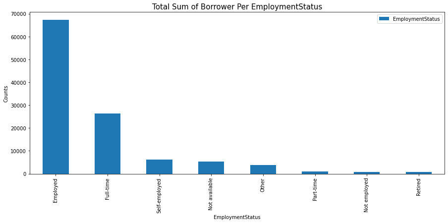

# Distribution of Stated Monthly Income

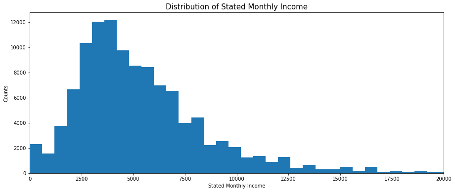

# Correlation Between Different Numerical Variables

- The visualization shows the correlation between different numerical variables. The borrower interest Rate and loan original amount are negatively correlated, which means the more the loan amount, the lower the Borrower Rate.
- The loan original amount is positively correlated to the stated monthly income. That is, the higher their stated monthly income, the higher the loan amount

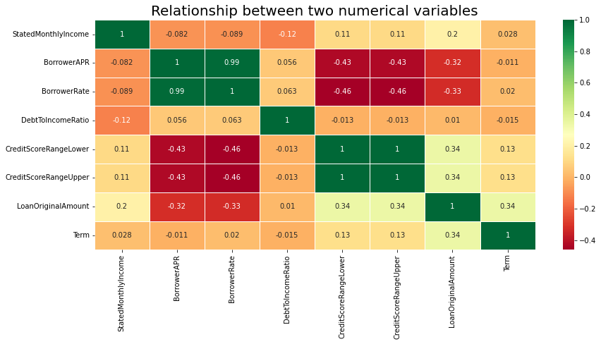

# Distribution of Borrower State

- Of all State, State with CA tends to have the highest number of borrower.

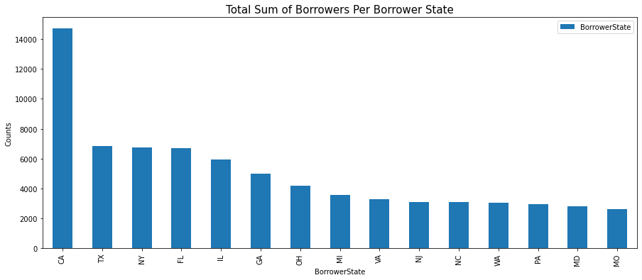

# Distribution of Term

- The Pie chart below shows that most borrowers have 36 months Term

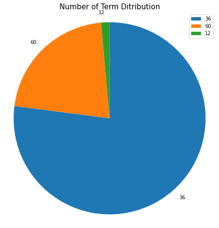

# Relationship Between The Loan Original Amount and Term Based Income Verifiable

- The Visualiation shows that higher the orignal amount of the loan, the higher length of the loan express in months

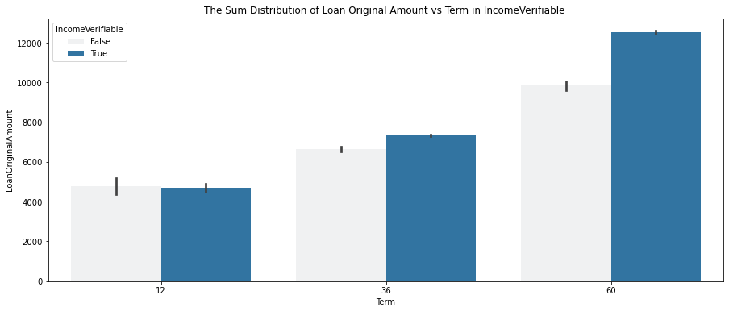